# PG1-Report

## Loading and preprocessing the data - (Question 1)

To make the script reusable & reproducible, we will script to download and pre-process data

```r
fileURL <- "https://d396qusza40orc.cloudfront.net/repdata%2Fdata%2Factivity.zip"
destFile <- "~/coursera/datascience/Course5-ReproducibleResearch/Week2/data.zip"
xtract <- "~/coursera/datascience/Course5-ReproducibleResearch/Week2"
fileName <- paste(xtract,"/activity.csv",sep="")

download.file(fileURL, destfile = destFile )
unzip(destFile, exdir = xtract)

if(file.exists(fileName)){
  actData <- read.csv(fileName,na.strings = "NA")
  # adding a new factor variable to the orignal data set
  actData <- data.frame(actData, daytype = ifelse(is.weekend(as.Date(actData$date, "%Y-%m-%d")),"Weekend","Weekday"))

}
```

## Let us look at the summary and sturcture of the data

```r
summary(actData)
```

```
##      steps                date          interval         daytype
##  Min.   :  0.00   2012-10-01:  288   Min.   :   0.0   Weekday:12960
##  1st Qu.:  0.00   2012-10-02:  288   1st Qu.: 588.8   Weekend: 4608
##  Median :  0.00   2012-10-03:  288   Median :1177.5
##  Mean   : 37.38   2012-10-04:  288   Mean   :1177.5
##  3rd Qu.: 12.00   2012-10-05:  288   3rd Qu.:1766.2
##  Max.   :806.00   2012-10-06:  288   Max.   :2355.0
##  NA's   :2304     (Other)   :15840
```

```r
str(actData)
```

```
## 'data.frame':    17568 obs. of  4 variables:
##  $ steps   : int  NA NA NA NA NA NA NA NA NA NA ...
##  $ date    : Factor w/ 61 levels "2012-10-01","2012-10-02",..: 1 1 1 1 1 1 1 1 1 1 ...
##  $ interval: int  0 5 10 15 20 25 30 35 40 45 ...
##  $ daytype : Factor w/ 2 levels "Weekday","Weekend": 1 1 1 1 1 1 1 1 1 1 ...
```

## What is mean total number of steps taken per day?

Aggregate or group the data by date/5-mintes slot to find the total number of steps taken for a day. Using qplot function render histogram(using geom function) - **(Question 2)**

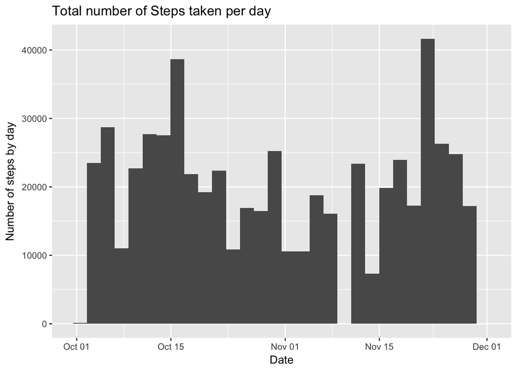

```r
aggrS <- aggregate(actData$steps, by=list(as.Date(actData$date,"%Y-%m-%d")),sum)
colnames(aggrS) <- c("Date","NumSteps")
qplot(aggrS$Date, xlab = "Date", ylab="Number of steps by day", main ="Total number of Steps taken per day") + geom_histogram(aes(weight=aggrS$NumSteps))
```

## What is the average daily activity pattern?

Aggregate or group the data by date/5-mintes slot to find the mean/average number of steps taken for a day. Using qplot function render histogram(using geom function) - **(Question 3)**

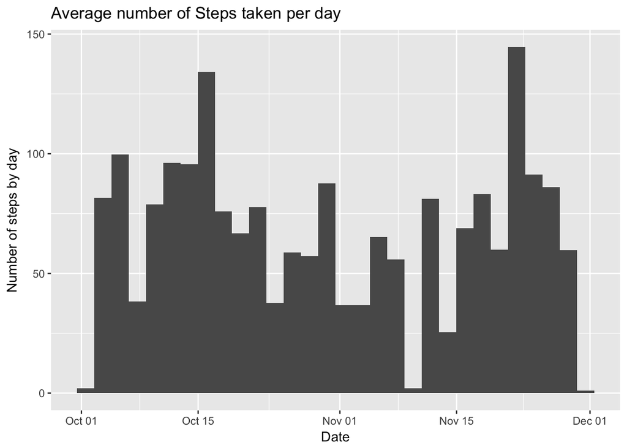

```r
aggrMn <- aggregate(actData$steps, by=list(as.Date(actData$date,"%Y-%m-%d")),mean)
colnames(aggrMn) <- c("Date","NumSteps")
qplot(aggrMn$Date, xlab = "Date", ylab="Number of steps by day", main ="Average number of Steps taken per day") + geom_histogram(aes(weight = aggrMn$NumSteps))
```

Similarly, plot the **median** number of steps taken per day.- **(Question 3)**

[figure not shown]

```r
aggrMd <- aggregate(actData$steps, by=list(as.Date(actData$date,"%Y-%m-%d")),median)
colnames(aggrMd) <- c("Date","NumSteps")
qplot(aggrMd$Date, xlab = "Date", ylab="Number of steps by day", main ="Median of steps taken per day") + geom_histogram(aes(weight = aggrMd$NumSteps))
```

Timeseries plot of average number of steps taken. - **(Question 4)**

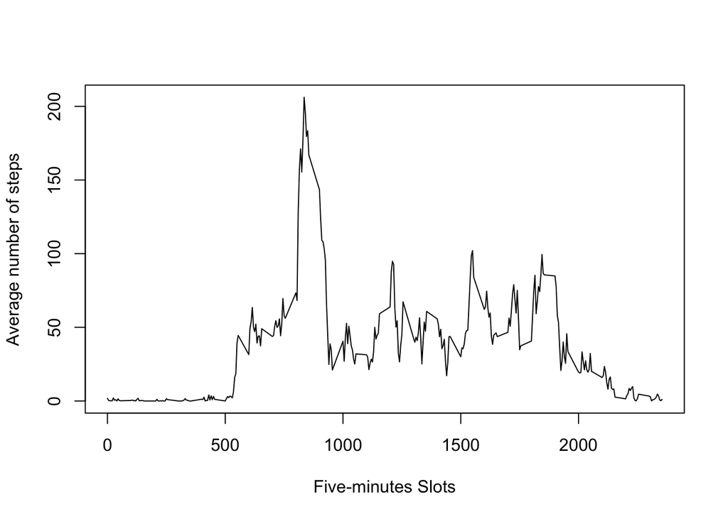

```r
interAggrMn <- aggregate(actData$steps, by= list(actData$interval), mean, na.rm= TRUE)
colnames(interAggrMn) <- c("Slot","NumSteps")
plot(interAggrMn$Slot,interAggrMn$NumSteps, type="l", xlab="Five-minutes Slots", ylab = "Average number of steps", alpha=0.7)
```

Five minute interval that, on average, contains the maximum number of steps - **(Question 5)**

```r
interAggrMn[which.max(interAggrMn$NumSteps),]
```

```
##     Slot NumSteps
## 104  835 206.1698
```

## Imputing missing values - (Question 6)

Firstly, let us look at the number of NAs by columns in the original data set.

```r
colSums(sapply(actData,is.na))
```

```
##    steps     date interval  daytype
##     2304        0        0        0
```

Based, on the output above, vairable =*steps* alone has NAs that needs to imputed. I chose *HMisc based impute function using mean method* compared to other impute options such as * missForest, KNN* etc. in view of the single variant imputing needed for this situation. Also, the percentage of NA’s is only 13% of the whole data set and in one column. A new activity data set with all NAs replaced with imputed values is created as in the code snippent above, using which the subsequent computation and ploting is performed.

```r
narows <- which(is.na(actData$steps))
i<- impute(actData$steps,mean)
newactData <- data.frame(actData)
newactData$steps[narows] <- i[narows]
```

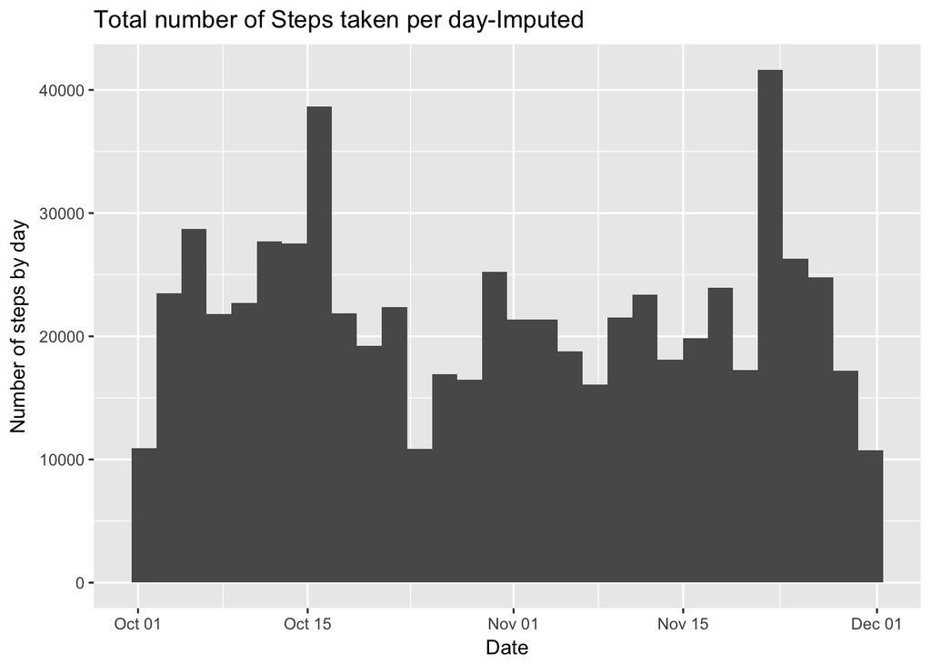

```r
newaggrS <- aggregate(newactData$steps, by=list(as.Date(newactData$date,"%Y-%m-%d")),sum)
colnames(newaggrS) <- c("Date","NumSteps")
qplot(newaggrS$Date, xlab = "Date", ylab="Number of steps by day", main ="Total number of Steps taken per day-Imputed") + geom_histogram(aes(weight=newaggrS$NumSteps))
```

Aggregate the imputed data by interval and find the mean of steps taken per day & type of day (Weekday or Weend) and plot in two panels - **(Question 8)**

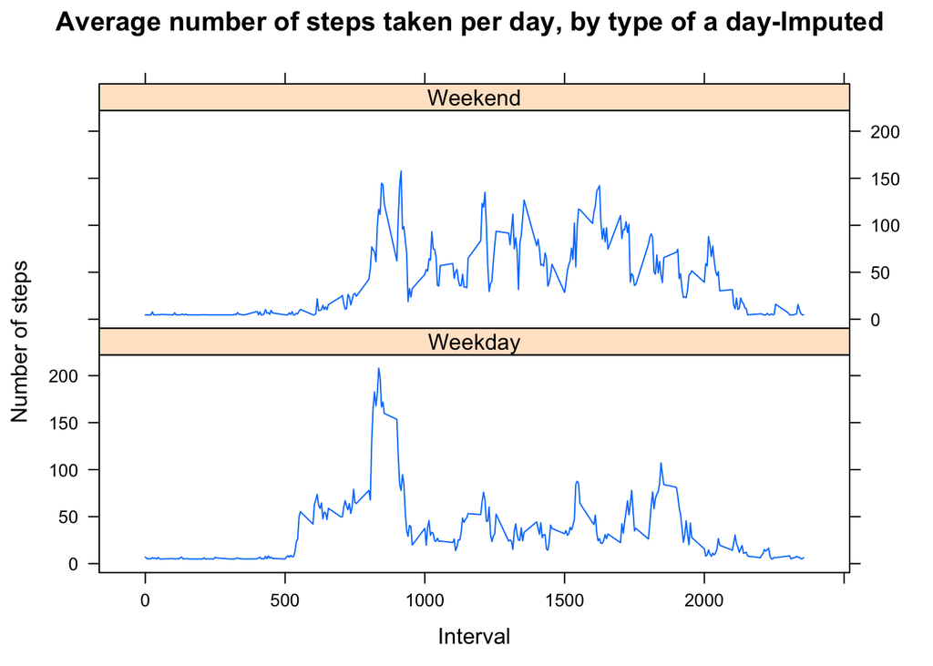

```r
newinterAggrMn2 <- aggregate(newactData$steps, by= list(newactData$interval,newactData$daytype), mean)
colnames(newinterAggrMn2) <- c("Slot","daytype","NumSteps")
xyplot(NumSteps ~ Slot | daytype, data = newinterAggrMn2, type = "l", layout=c(1,2), ylab = "Number of steps", main = " Average number of steps taken per day, by type of a day-Imputed", xlab = "Interval")
```

```r
tot <- aggregate(newactData$steps, by = list(newactData$daytype), sum)
```

[output not shown]